# module7

groupe2

2025-03-26

```r
#install.packages("leaps")
library(leaps)
library(glmnet)
library(ISLR2)
library(dplyr)
library(rsample)
```

### Question 1

Nous effectuons la sélection du meilleur sous-ensemble, en avant et en arrière sur un seul ensemble de données. Pour chaque approche, nous obtenons des modèles p+1 contenant des prédicteurs 0,1 …p

Répondons aux questions

#### a

Lequel des trois modèles avec des prédicteurs k a le plus petit RSS d’entraînement ?

**Rép :** C’est le meilleur sous ensemble qui doit avoir le plus petit RSS d’entrainement. D’après sa définition, le meilleur sous ensemble est le meilleur modèle parmi toutes les possibilités.

#### b

Lequel des trois modèles avec des prédicteurs k a le plus petit RSS test ?

**Rép:** Je pense que c’est la selection en arrière qui a le plus petit RSS test, car il prend toutes les variables et élimine progressivement celles qui ne sont pas neccessaires.Cette facon de faire permet de diminuer progressivement l’effet du sur ajustement jusqu’à satisfaction.

#### c Répondre par vrai ou faux

i- Vrai

ii- Vrai

iii- Faux

iv- Faux

v- Faux

### Question 2

a -iii

Le LASSO est moins flexible que le moindre carré, car il force certain coefficient à être nulls.

b - iii Pour les même raisons que précédament

### Question 3

a - iV

lorsque s=0, on a le modele null = le plus rigide possible, le RSS de formation(ou d’entrainement est le plus grand possible. ). à mesure que s augmente, les beta_j ont tendance à prendre n’importe quelle valeur possible, ce qui augmente la flexibilité du modèle.–> lee modèle tend à épouser les données d’entrainement avec pour limite le modèle des moindres carrés. donc le RSS d’entrainement tend à diminuer progressivement jusqu’à la limite du RSS des moindres carrés

b- ambigü, il n’y a pas s ici

c - idème

d- idème

e - idème

### Question 4

a- iii

si Lambda =0, le modele est égal au modèle de regression linéaire des moindre carrées.La presence de lambda a pour effet de penaliser les coefficients et les rendre moin flexible. à mesure que lambda augmente, cette pénalité est considerable et le modèle devient plus rigide –> Le RSS de formation va donc augmenter continuellement, partant de la valeur du RSS du modèle linéaire des moindres carrées avec toutes les variable, jusqu’à celle du modèle vide.

b- ambigu

c- ideme

d- ideme

e- ideme

## Pratique

### Pratique : Exercice 1

```r
set.seed(2025)
#a
X <- rnorm(100, mean = 0, sd = 1)
epsilon <- rnorm(100, mean = 0, sd = 1)

#b-  vecteur reponse

beta_0 <- 4
beta_1 <- 5
beta_2 = -3
beta_3 = 2

Y <- beta_0 + beta_1 * X + beta_2*X^2 +  beta_3*X^3 + epsilon
```

```r
#c

data <- data.frame(Y, X)
for (i in 4:10) {
  data[[paste0("X", i)]] <- X^i
}

regfit.full <- regsubsets(Y ~ ., data = data, nvmax = 10)
reg.summary <- summary(regfit.full)

# Quel est le meilleur modèle obtenu selon R^2 ajusté, Cp, et BIC


meilleur_adj_r2 = which.max(reg.summary$adjr2)

cat("\n meilleur modelle selon r2 ajusté : celui avec " , meilleur_adj_r2 , "variables")
```

```
##
##  meilleur modelle selon r2 ajusté : celui avec  8 variables
```

```r
meilleur_cp <- which.min(reg.summary$cp)

cat("\n meilleur modele selon Cp :  celui avec " , meilleur_cp , "variables" )
```

```
##
##  meilleur modele selon Cp :  celui avec  8 variables
```

```r
meilleur_bic <- which.min(reg.summary$bic)

cat("\n meilleur modele selon BIC : celui avec " , meilleur_bic, "variables " )
```

```
##
##  meilleur modele selon BIC : celui avec  7 variables
```

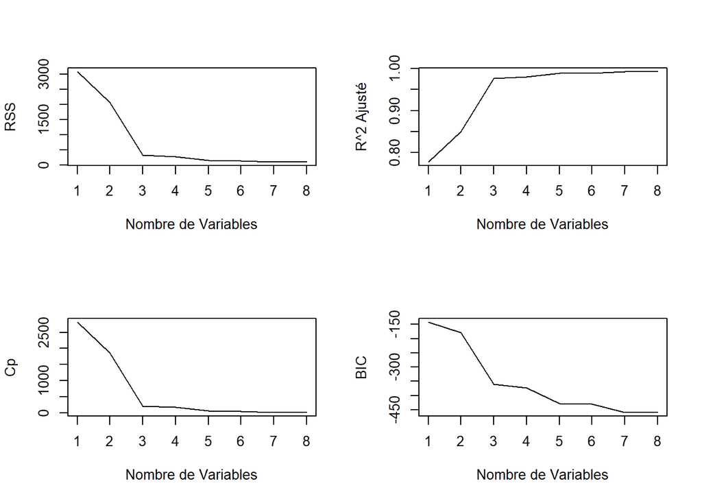

```r
#Representations graphiques

par(mfrow = c(2, 2))
plot(reg.summary$rss, xlab = "Nombre de Variables", ylab = "RSS", type = "l")
plot(reg.summary$adjr2, xlab = "Nombre de Variables", ylab = "R^2 Ajusté", type = "l")
plot(reg.summary$cp, xlab = "Nombre de Variables", ylab = "Cp", type = "l")
plot(reg.summary$bic, xlab = "Nombre de Variables", ylab = "BIC", type = "l")
```

```r
data("College")
head(College)
```

```
##                              Private Apps Accept Enroll Top10perc Top25perc
## Abilene Christian University     Yes 1660   1232    721        23        52
## Adelphi University               Yes 2186   1924    512        16        29
## Adrian College                   Yes 1428   1097    336        22        50
## Agnes Scott College              Yes  417    349    137        60        89
## Alaska Pacific University        Yes  193    146     55        16        44
## Albertson College                Yes  587    479    158        38        62
##                              F.Undergrad P.Undergrad Outstate Room.Board Books
## Abilene Christian University        2885         537     7440       3300   450
## Adelphi University                  2683        1227    12280       6450   750
## Adrian College                      1036          99    11250       3750   400
## Agnes Scott College                  510          63    12960       5450   450
## Alaska Pacific University            249         869     7560       4120   800
## Albertson College                    678          41    13500       3335   500
##                              Personal PhD Terminal S.F.Ratio perc.alumni Expend
## Abilene Christian University     2200  70       78      18.1          12   7041
## Adelphi University               1500  29       30      12.2          16  10527
## Adrian College                   1165  53       66      12.9          30   8735
## Agnes Scott College               875  92       97       7.7          37  19016
## Alaska Pacific University        1500  76       72      11.9           2  10922
## Albertson College                 675  67       73       9.4          11   9727
##                              Grad.Rate
## Abilene Christian University        60
## Adelphi University                  56
## Adrian College                      54
## Agnes Scott College                 59
## Alaska Pacific University           15
## Albertson College                   55
```

```r
set.seed(2025)
split <- initial_split(College, prop = 0.8)
train_data <- training(split)
test_data <- testing(split)

# Question b modele lineaire

lm_model <- lm(Outstate ~ ., data = train_data)
summary(lm_model)
```

```
##
## Call:
## lm(formula = Outstate ~ ., data = train_data)
##
## Residuals:
##     Min      1Q  Median      3Q     Max
## -7175.5 -1328.4   -44.7  1278.9  9867.1
##
## Coefficients:
##               Estimate Std. Error t value Pr(>|t|)
## (Intercept) -901.25683  898.77974  -1.003   0.3164
## PrivateYes  2438.10383  279.98890   8.708  < 2e-16 ***
## Apps          -0.23625    0.07781  -3.036   0.0025 **
## Accept         0.81278    0.14299   5.684 2.05e-08 ***
## Enroll        -0.81416    0.40514  -2.010   0.0449 *
## Top10perc     26.99952   12.12704   2.226   0.0264 *
## Top25perc     -5.91629    9.30312  -0.636   0.5251
## F.Undergrad   -0.05325    0.06988  -0.762   0.4463
## P.Undergrad   -0.07712    0.09158  -0.842   0.4000
## Room.Board     0.89526    0.10068   8.892  < 2e-16 ***
## Books         -0.84064    0.53552  -1.570   0.1170
## Personal      -0.22602    0.14583  -1.550   0.1217
## PhD           13.90374    9.52576   1.460   0.1449
## Terminal      20.43953   10.37109   1.971   0.0492 *
## S.F.Ratio    -50.65327   28.49237  -1.778   0.0759 .
## perc.alumni   42.50975    8.75127   4.858 1.52e-06 ***
## Expend         0.20672    0.02869   7.205 1.74e-12 ***
## Grad.Rate     16.16376    6.43226   2.513   0.0122 *
## ---
## Signif. codes:  0 '***' 0.001 '**' 0.01 '*' 0.05 '.' 0.1 ' ' 1
##
## Residual standard error: 1980 on 603 degrees of freedom
## Multiple R-squared:  0.7557, Adjusted R-squared:  0.7488
## F-statistic: 109.7 on 17 and 603 DF,  p-value: < 2.2e-16
```

```r
predictions <- predict(lm_model, newdata = test_data)
erreur <- sqrt(mean((test_data$Outstate - predictions)^2))
cat("RMSE de test = ", erreur)
```

```
## RMSE de test =  1927.804
```

### c

```r
x_train <- model.matrix(Outstate ~ ., train_data)[, -1]
y_train <- train_data$Outstate

set.seed(2025)
cv_ridge <- cv.glmnet(x_train, y_train, alpha = 0, nfolds = 10)  # alpha=0 pour Ridge
print(cv_ridge)
```

```
##
## Call:  cv.glmnet(x = x_train, y = y_train, nfolds = 10, alpha = 0)
##
## Measure: Mean-Squared Error
##
##     Lambda Index Measure     SE Nonzero
## min  264.7   100 4119374 232140      17
## 1se 1550.6    81 4326843 267772      17
```

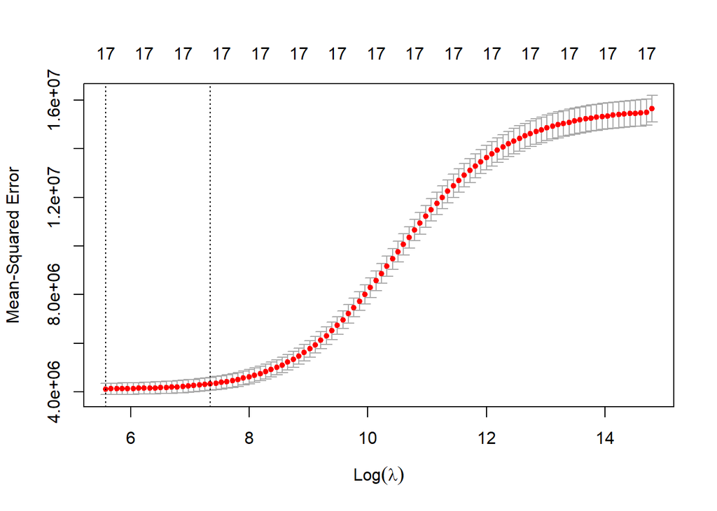

```r
plot(cv_ridge)
```

```r
meilleur_lambda <- cv_ridge$lambda.min
cat("Meilleur lambda choisi par validation croisée : ", meilleur_lambda, "\n")
```

```
## Meilleur lambda choisi par validation croisée :  264.7343
```

```r
ridge_model <- glmnet(x_train, y_train, alpha = 0, lambda = meilleur_lambda)

x_test <- model.matrix(Outstate ~ ., test_data)[, -1]
y_test <- test_data$Outstate


predictions <- predict(ridge_model, s = meilleur_lambda, newx = x_test)

erreur_ridge <- sqrt(mean((y_test - predictions)^2))
cat("Erreur de test (RMSE): ", erreur_ridge, "\n")
```

```
## Erreur de test (RMSE):  1928.865
```

### d

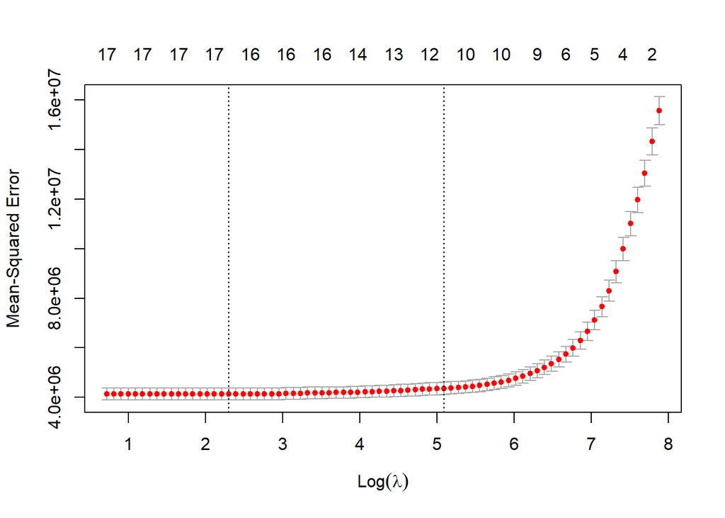

```r
set.seed(2025)
cv.lasso <- cv.glmnet(x_train, y_train, alpha = 1)
plot(cv.lasso)
```

```r
meilleur_lambda <- cv.lasso$lambda.min
print(paste("Meilleur lambda (lasso) :", meilleur_lambda))
```

```
## [1] "Meilleur lambda (lasso) : 9.96707706207282"
```

```r
predictions_lasso <- predict(cv.lasso, s = meilleur_lambda, newx = x_test)
mse_lasso <- mean((predictions_lasso - y_test)^2)
print(paste("Erreur quadratique moyenne (MSE) sur le test :", round(mse_lasso, 2)))
```

```
## [1] "Erreur quadratique moyenne (MSE) sur le test : 3720282.37"
```

```r
coeff_lasso <- predict(cv.lasso, type = "coefficients", s = meilleur_lambda)
non_zero <- sum(coeff_lasso != 0) - 1
print(paste("Nombre de coefficients non nuls :", non_zero))
```

```
## [1] "Nombre de coefficients non nuls : 16"
```